# Example Workflow for Bulk RNA-seq Analysis with limma-voom

[cw](https://cying.org)

2026-10-07

```r
litedown::reactor(warning = FALSE) # vignette setting

library(easybio)
```

This vignette provides a step-by-step guide on how to perform bulk RNA-Seq analysis using the Limma-voom workflow. It is designed to be a comprehensive resource for researchers looking to analyze gene expression data from projects such as TCGA. You can view an example script for this workflow by running the following command

```r
file.show(system.file(package = 'easybio', 'example-bulk-rna-seq.R'))
```

## Limma-voom workflow

### Prepare data

For downloading and processing datasets from the Gene Expression Omnibus (GEO), utilize the `prepare_geo()` function. This function will generate a list containing count data, sample information, and gene data.

### Example Workflow: TCGA CHOL Project

```r
library(TCGAbiolinks)
library(data.table)

query <- GDCquery(
  project = "TCGA-CHOL",
  data.category = "Transcriptome Profiling",
  data.type = "Gene Expression Quantification"
)
GDCdownload(query = query)
data <- GDCprepare(query = query)

lt <- prepare_tcga(data)
lt$all$sample_info[["group"]] <- fifelse(lt$all$sample_info$sample_type %ilike% "Tumor", "Tumor", "Normal")

# limma-voom workflow
x <- dge_list(lt$all$expr_count, lt$all$sample_info, lt$all$features_info)
x <- process_dge_list(x, "group", 10)
efit <- limma_fit(x, "group")
get_attr(efit, "contrast")

CHOL_DEGs <- limma::topTable(fit = efit, coef = 1, number = Inf)
```

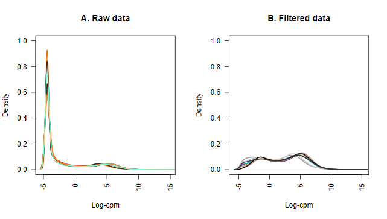

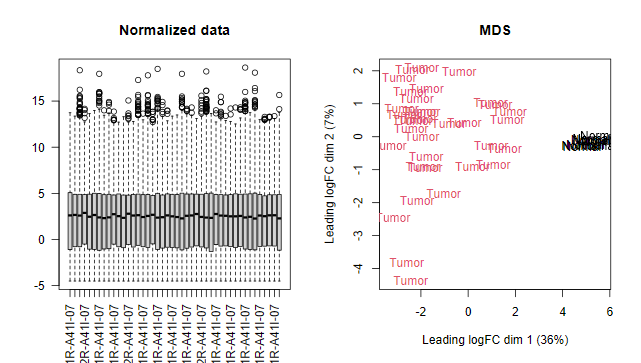

Set the criteria for differential gene expression:

```r
CHOL_DEGs[, let(
  tumor_vs_normal = fcase(
    adj.P.Val < 0.05 & logFC > 2, "Up",
    adj.P.Val < 0.05 & logFC < -2, "Down",
    default = "Not-Significant"
  )
)]
setDT(CHOL_DEGs, keep.rownames = "rid")
head(CHOL_DEGs)
```

Visualize the differentially expressed genes (DEGs) with a volcano plot:

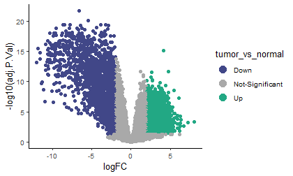

```r
data(CHOL_DEGs)
plot_volcano(
  data = CHOL_DEGs,
  x = logFC,
  y = -log10(adj.P.Val),
  color = tumor_vs_normal
)
```

For pathway enrichment analysis, such as GO and KEGG, download the `r4msigdb` package to access the MSigDB gene sets. For more details on this package, please see r4msigdb.

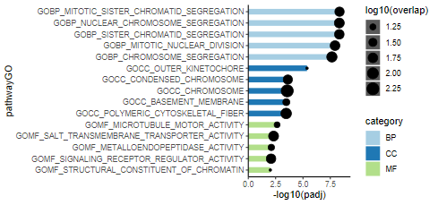

```r
# devtools::install_github('person-c/easybio')
library(data.table)
# Over Presentation Analysis(ORA)
pathwayGO <- r4msigdb::query("Hs", pathway = "^GO(BP|CC|MF)_")
pathwayGO <- setNames(pathwayGO$symbol, pathwayGO$standard_name)

oraRes <- fgsea::fora(
  pathways = pathwayGO,
  genes = CHOL_DEGs[.("Up"), gene_name, on = .(tumor_vs_normal)],
  universe = unique(CHOL_DEGs$gene_name)
)
oraRes[, let(
  category = fcase(
    pathway %like% "GOBP", "BP",
    pathway %like% "GOMF", "MF",
    pathway %like% "GOCC", "CC"
  )
)]

oraRes <- oraRes[, .SD[order(padj)], by = .(category)]
oraRes[, let(pathwayGO = factor(pathway, levels = rev(pathway)))]
plot_ora(
  data = oraRes[, head(.SD, 5), by = category],
  x = -log10(padj),
  y = pathwayGO,
  size = log10(overlap),
  fill = category
)
```

```r
library(fgsea)
data(examplePathways)
data(exampleRanks)
```

Run the GSEA analysis:

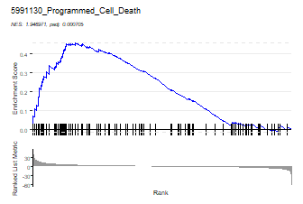

```r
fgsea_res <- fgsea(
  pathways = examplePathways,
  stats = exampleRanks,
  minSize = 15,
  maxSize = 500,
  # Run on one thread. fgsea otherwise hands the multilevel step to a
  # BiocParallel worker, which intermittently fails to find fgsea's own
  # compiled function and aborts the vignette build ("could not find function
  # fgseaMultilevelCpp"). nproc = 1 does not help: setUpBPPARAM() assigns
  # SerialParam() for it and then overwrites it with MulticoreParam(workers = 1),
  # so the backend has to be passed in. The example is small enough that the
  # parallelism buys nothing.
  BPPARAM = BiocParallel::SerialParam()
)
plot_gsea(
  fgsea_res,
  pathways = examplePathways,
  pwayname = "5991130_Programmed_Cell_Death",
  stats = exampleRanks,
  save = FALSE
)
```